# R Notebook

Neil Yetz & Gemma Wallace

# Load Libraries

`r`r library(psych) library(tidyverse) library(lme4) library(lmerTest) library(broom) library(modelr)

# class demo dataset

`r`r #Wide dataset will convert to long below wide <- read_csv(_grow.csv)

# Format and output class demo

`r`r ###### Stolen from Kim Start ####### long_perf <- wide %>% select(kid_id, txcond, perf_0:perf_6) %>% gather(key = measure, value = perform, perf_0:perf_6) %>% separate(measure, c(, )) %>% select(-temp) %>% mutate(week = as.numeric(week)) long_inter <- wide %>% select(kid_id, inter_0:inter_6) %>% gather(key = measure, value = interest, inter_0:inter_6) %>% separate(measure, c(, )) %>% select(-temp) %>% mutate(week = as.numeric(week)) grow <- full_join(long_perf, long_inter, by = c(_id, )) grow <- grow %>% mutate(txcond.f = factor(txcond, levels = c(0,1), labels = c(, )), kid_id.f = factor(kid_id)) ###### Stolen From Kim End ###### # Simplify dataset grow <- select(grow, kid_id, week, perform) # Write to csv write_csv(grow, .csv, na = \)

# Read in Data

`r`r grow <- read_csv(.csv)

# Describe data

`r`r describe(grow)

|  | vars | n | mean | sd | median | trimmed | mad | min | max | range | skew | kurtosis | se |
| --- | --- | --- | --- | --- | --- | --- | --- | --- | --- | --- | --- | --- | --- |
| kid_id | 1 | 700 | 252.5 | 144.43 | 252.50 | 252.50 | 185.32 | 5.00 | 500 | 495.00 | 0.00 | -1.21 | 5.46 |
| week | 2 | 700 | 3.0 | 2.00 | 3.00 | 3.00 | 2.97 | 0.00 | 6 | 6.00 | 0.00 | -1.25 | 0.08 |
| perform | 3 | 700 | 4.9 | 1.33 | 4.88 | 4.87 | 1.32 | 1.27 | 10 | 8.73 | 0.29 | 0.20 | 0.05 |

# Visualize the data

`r`r ggplot(grow, aes(x = week, y = perform)) + geom_jitter(aes(color = factor(week))) + geom_smooth(method = , color = , size = 2) + xlab() + ylab() + labs(color = )

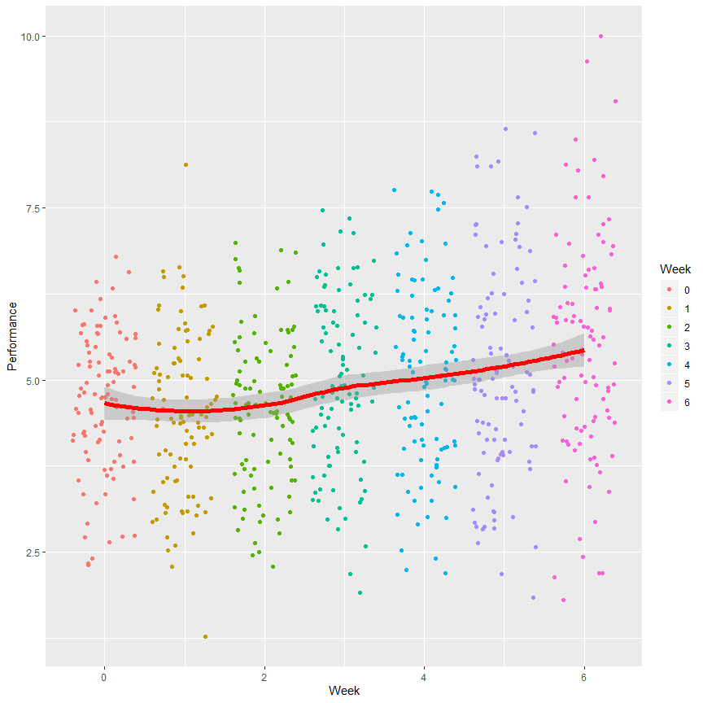

# Baseline model

`r`r mod1 <- lmer(perform ~ 1 + (1|kid_id), REML = TRUE, data = grow) summary(mod1)

```
Linear mixed model fit by REML. t-tests use Satterthwaite's method ['lmerModLmerTest']
Formula: perform ~ 1 + (1 | kid_id)
   Data: grow

REML criterion at convergence: 2166.1

Scaled residuals:
    Min      1Q  Median      3Q     Max
-2.6469 -0.6424 -0.0085  0.5990  3.2746

Random effects:
 Groups   Name        Variance Std.Dev.
 kid_id   (Intercept) 0.8013   0.8951
 Residual             0.9821   0.9910
Number of obs: 700, groups:  kid_id, 100

Fixed effects:
            Estimate Std. Error       df t value Pr(>|t|)
(Intercept)  4.90455    0.09703 98.99999   50.55   <2e-16 ***
---
Signif. codes:  0 â€˜***â€™ 0.001 â€˜**â€™ 0.01 â€˜*â€™ 0.05 â€˜.â€™ 0.1 â€˜ â€™ 1
```

# Separated by subject

`r`r ggplot(data = grow, aes(x = week, y = perform)) + geom_point() + geom_smooth(method = , se = FALSE) + scale_y_continuous(limits = c(0,10)) + scale_x_continuous(limits = c(0,6), breaks = c(0,1,2,3,4,5,6)) + facet_wrap(~kid_id) + labs(title = students in the control condition improve their task performance over the course of the program?, x = in the program, y = Performance)

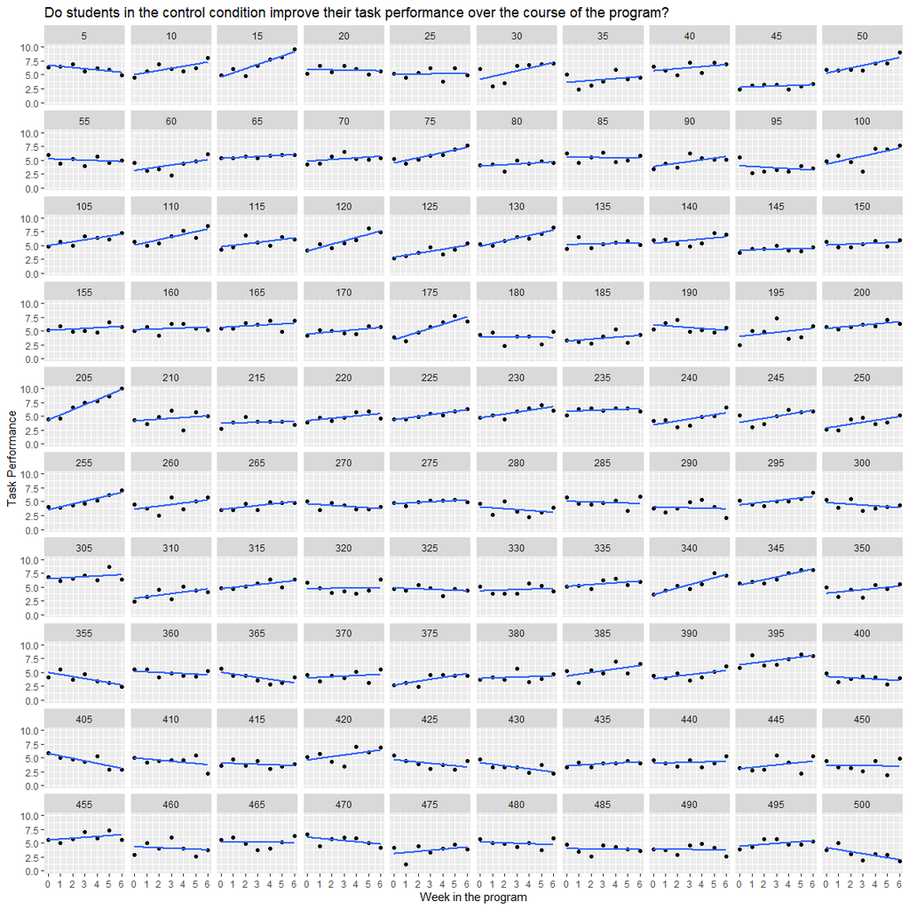

`r`r mod2 <- lmer(perform ~ 1 + week + (1 + week|kid_id), REML = TRUE, data = grow) summary(mod2)

```
Linear mixed model fit by REML. t-tests use Satterthwaite's method ['lmerModLmerTest']
Formula: perform ~ 1 + week + (1 + week | kid_id)
   Data: grow

REML criterion at convergence: 2038.4

Scaled residuals:
    Min      1Q  Median      3Q     Max
-3.1997 -0.5740  0.0449  0.6342  3.0608

Random effects:
 Groups   Name        Variance Std.Dev. Corr
 kid_id   (Intercept) 0.42532  0.6522
          week        0.03774  0.1943   0.10
 Residual             0.71247  0.8441
Number of obs: 700, groups:  kid_id, 100

Fixed effects:
            Estimate Std. Error       df t value Pr(>|t|)
(Intercept)  4.47310    0.08695 98.99841  51.442  < 2e-16 ***
week         0.14382    0.02514 99.00129   5.722 1.13e-07 ***
---
Signif. codes:  0 â€˜***â€™ 0.001 â€˜**â€™ 0.01 â€˜*â€™ 0.05 â€˜.â€™ 0.1 â€˜ â€™ 1

Correlation of Fixed Effects:
     (Intr)
week -0.292
```

`r`r # Get predicted values mod2.plot <- add_predictions(data = grow, model = mod2) # Make plot ggplot(data = mod2.plot, aes(x = week, y = pred, group = kid_id)) + geom_line(color = 53) + geom_abline(intercept = 4.4731, slope = .1438, color=, size=3) + scale_y_continuous(limits = c(0,10)) + scale_x_continuous(limits = c(0,6), breaks = c(0,1,2,3,4,5,6)) + labs(title = students improve on task performance over the course of the program?, x = , y = Performance) + theme_bw()

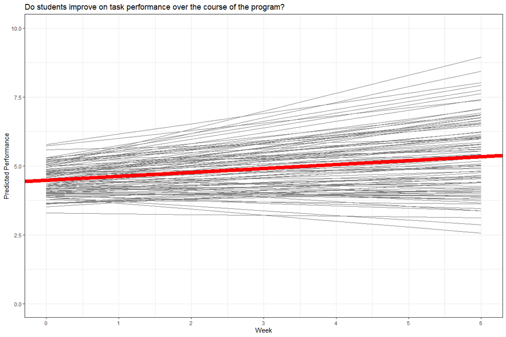

# read in data

`r`r long <- read_csv(.csv)

# Describe data

`r`r describe(long)

|  | vars | n | mean | sd | median | trimmed | mad | min | max | range | skew | kurtosis | se |
| --- | --- | --- | --- | --- | --- | --- | --- | --- | --- | --- | --- | --- | --- |
| student | 1 | 1200 | 100.50 | 57.76 | 100.5 | 100.50 | 74.13 | 1.0 | 200 | 199.0 | 0.00 | -1.20 | 1.67 |
| occas | 2 | 1200 | 2.50 | 1.71 | 2.5 | 2.50 | 2.22 | 0.0 | 5 | 5.0 | 0.00 | -1.27 | 0.05 |
| gpa | 3 | 1200 | 2.87 | 0.39 | 2.8 | 2.86 | 0.44 | 1.7 | 4 | 2.3 | 0.18 | -0.02 | 0.01 |
| job | 4 | 1200 | 0.50 | 0.50 | 0.5 | 0.50 | 0.74 | 0.0 | 1 | 1.0 | 0.00 | -2.00 | 0.01 |
| sex | 5 | 1200 | 0.52 | 0.50 | 1.0 | 0.53 | 0.00 | 0.0 | 1 | 1.0 | -0.10 | -1.99 | 0.01 |

# Factor variables

`r`r long <- mutate(long, job = factor(job, levels = c(0,1), labels = c(time, time)), sex = factor(sex, levels = c(0,1), labels = c(, )) )

# Create occas squared

`r`r long <- mutate(long, occassq = occas**2)

# Aggregate data

`r`r agg_long <- aggregate(x=long$gpa,by=list(occasion = long$occas), FUN=mean) agg_long

| occasion | x |
| --- | --- |
| 0 | 2.5935 |
| 1 | 2.7155 |
| 2 | 2.8100 |
| 3 | 2.9180 |
| 4 | 3.0190 |
| 5 | 3.1340 |

`r`r ggplot(agg_long, aes(x = occasion, y = x)) + geom_line() + ylab()

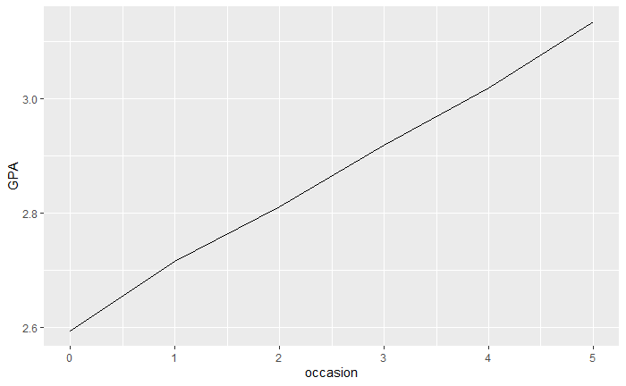

`r`r NA

`r`r ggplot(long, aes(x = occas, y = gpa)) + geom_jitter(aes(color = factor(occas))) + geom_smooth(method = , color = , size = 2) + xlab() + labs(color = )

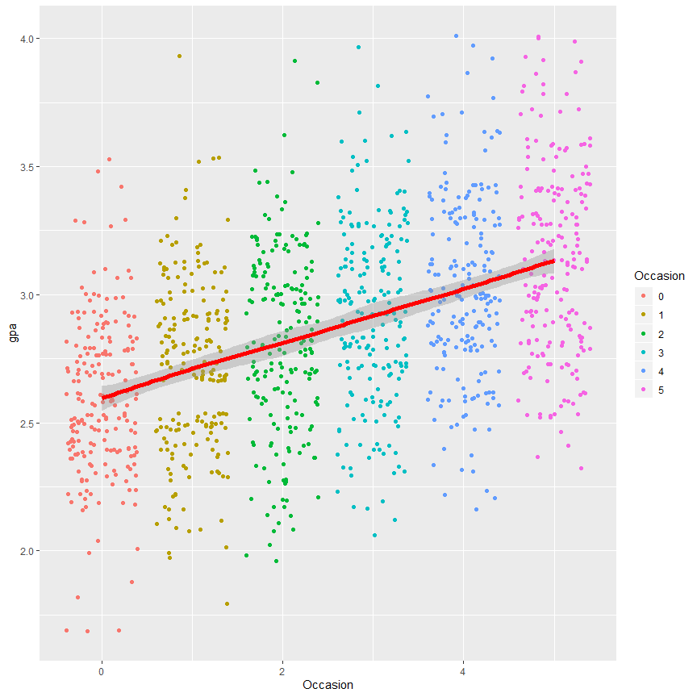

`r`r ggplot(long, aes(x = occas, y = gpa)) + geom_jitter(aes(color = factor(occas))) + geom_smooth(method = , color = , size = 2) + xlab() + labs(color = ) + facet_wrap(~sex)

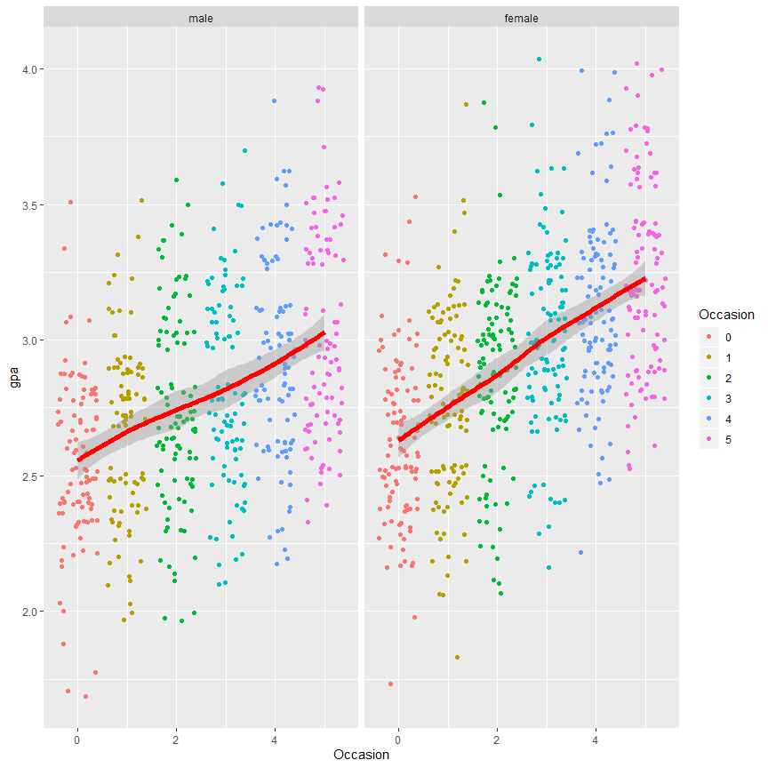

`r`r ggplot(data = long, aes(x = occas, y = gpa)) + geom_point() + geom_smooth(method = , se = FALSE) + facet_wrap(~student) + labs(title = students increase in GPA across occasion?, x = , y = )

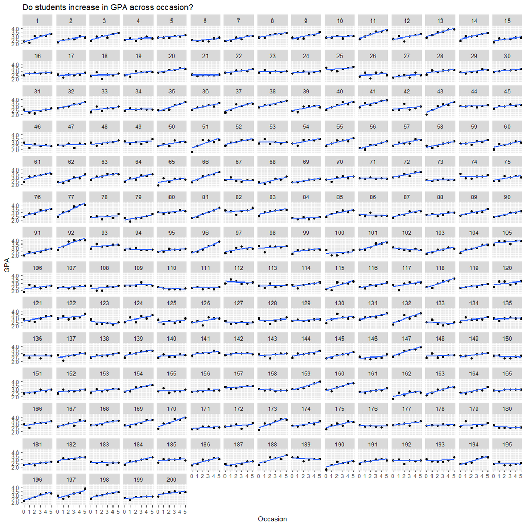

# Baseline model

`r`r mod1 = lmer(gpa ~ 1 + (1|student), REML = TRUE, data = long) summary(mod1)

```
Linear mixed model fit by REML. t-tests use Satterthwaite's method ['lmerModLmerTest']
Formula: gpa ~ 1 + (1 | student)
   Data: long

REML criterion at convergence: 919.5

Scaled residuals:
    Min      1Q  Median      3Q     Max
-3.6504 -0.5496  0.0603  0.6356  2.5736

Random effects:
 Groups   Name        Variance Std.Dev.
 student  (Intercept) 0.05714  0.2390
 Residual             0.09759  0.3124
Number of obs: 1200, groups:  student, 200

Fixed effects:
             Estimate Std. Error        df t value Pr(>|t|)
(Intercept)   2.86500    0.01916 198.99999   149.6   <2e-16 ***
---
Signif. codes:  0 â€˜***â€™ 0.001 â€˜**â€™ 0.01 â€˜*â€™ 0.05 â€˜.â€™ 0.1 â€˜ â€™ 1
```

# Added time as a random factor

`r`r mod2 = lmer(gpa ~ 1 + occas + (1 + occas|student), REML = TRUE, data = long) summary(mod2)

```
Linear mixed model fit by REML. t-tests use Satterthwaite's method ['lmerModLmerTest']
Formula: gpa ~ 1 + occas + (1 + occas | student)
   Data: long

REML criterion at convergence: 261

Scaled residuals:
    Min      1Q  Median      3Q     Max
-3.2696 -0.5377 -0.0128  0.5326  3.1938

Random effects:
 Groups   Name        Variance Std.Dev. Corr
 student  (Intercept) 0.045192 0.2126
          occas       0.004503 0.0671   -0.10
 Residual             0.042389 0.2059
Number of obs: 1200, groups:  student, 200

Fixed effects:
             Estimate Std. Error        df t value Pr(>|t|)
(Intercept) 2.599e+00  1.836e-02 1.990e+02  141.59   <2e-16 ***
occas       1.063e-01  5.884e-03 1.990e+02   18.07   <2e-16 ***
---
Signif. codes:  0 â€˜***â€™ 0.001 â€˜**â€™ 0.01 â€˜*â€™ 0.05 â€˜.â€™ 0.1 â€˜ â€™ 1

Correlation of Fixed Effects:
      (Intr)
occas -0.345
```

# ICC

ICC = variance for effect of interest / variance for effect + unexplained variance This is the underlying structure of the F statistic ICC for mod 2 = .005 / .005 + .042 = .106

Compare the ICCs across the different models

# Add covariate

`r`r mod4 = lmer(gpa ~ 1 + sex + (1|student), REML = TRUE, data = long) summary(mod4)

```
Linear mixed model fit by REML. t-tests use Satterthwaite's method ['lmerModLmerTest']
Formula: gpa ~ 1 + sex + (1 | student)
   Data: long

REML criterion at convergence: 908.8

Scaled residuals:
    Min      1Q  Median      3Q     Max
-3.5928 -0.5612  0.0553  0.6242  2.5290

Random effects:
 Groups   Name        Variance Std.Dev.
 student  (Intercept) 0.05200  0.2280
 Residual             0.09759  0.3124
Number of obs: 1200, groups:  student, 200

Fixed effects:
             Estimate Std. Error        df t value Pr(>|t|)
(Intercept)   2.78737    0.02681 197.99978 103.983  < 2e-16 ***
sexfemale     0.14787    0.03700 197.99978   3.997 9.05e-05 ***
---
Signif. codes:  0 â€˜***â€™ 0.001 â€˜**â€™ 0.01 â€˜*â€™ 0.05 â€˜.â€™ 0.1 â€˜ â€™ 1

Correlation of Fixed Effects:
          (Intr)
sexfemale -0.725
```

`r`r mod5 = lmer(gpa ~ 1 + occas + sex + (1 + occas|student), REML = TRUE, data = long) summary(mod5)

```
Linear mixed model fit by REML. t-tests use Satterthwaite's method ['lmerModLmerTest']
Formula: gpa ~ 1 + occas + sex + (1 + occas | student)
   Data: long

REML criterion at convergence: 255.8

Scaled residuals:
    Min      1Q  Median      3Q     Max
-3.1715 -0.5428 -0.0081  0.5317  3.2393

Random effects:
 Groups   Name        Variance Std.Dev. Corr
 student  (Intercept) 0.044345 0.21058
          occas       0.004504 0.06711  -0.16
 Residual             0.042388 0.20588
Number of obs: 1200, groups:  student, 200

Fixed effects:
             Estimate Std. Error        df t value Pr(>|t|)
(Intercept) 2.541e+00  2.542e-02 2.134e+02  99.981   <2e-16 ***
occas       1.063e-01  5.885e-03 1.990e+02  18.066   <2e-16 ***
sexfemale   1.100e-01  3.372e-02 1.980e+02   3.263   0.0013 **
---
Signif. codes:  0 â€˜***â€™ 0.001 â€˜**â€™ 0.01 â€˜*â€™ 0.05 â€˜.â€™ 0.1 â€˜ â€™ 1

Correlation of Fixed Effects:
          (Intr) occas
occas     -0.276
sexfemale -0.696  0.000
```

# Job + sex

`r`r mod6 = lmer(gpa ~ 1 + sex + job + (1|student), REML = TRUE, data = long) summary(mod6)

```
Linear mixed model fit by REML. t-tests use Satterthwaite's method ['lmerModLmerTest']
Formula: gpa ~ 1 + sex + job + (1 | student)
   Data: long

REML criterion at convergence: 912.8

Scaled residuals:
    Min      1Q  Median      3Q     Max
-3.6049 -0.5523  0.0553  0.6306  2.5162

Random effects:
 Groups   Name        Variance Std.Dev.
 student  (Intercept) 0.05208  0.2282
 Residual             0.09759  0.3124
Number of obs: 1200, groups:  student, 200

Fixed effects:
              Estimate Std. Error        df t value Pr(>|t|)
(Intercept)    2.80309    0.03225 196.99978  86.914  < 2e-16 ***
sexfemale      0.14885    0.03703 196.99978   4.019 8.31e-05 ***
jobfull time  -0.03247    0.03699 196.99978  -0.878    0.381
---
Signif. codes:  0 â€˜***â€™ 0.001 â€˜**â€™ 0.01 â€˜*â€™ 0.05 â€˜.â€™ 0.1 â€˜ â€™ 1

Correlation of Fixed Effects:
            (Intr) sexfml
sexfemale   -0.586
jobfulltime -0.555 -0.030
```

`r`r mod7 = lmer(gpa ~ 1 + occas + sex + job + (1+ occas|student), REML = TRUE, data = long) summary(mod7)

```
Linear mixed model fit by REML. t-tests use Satterthwaite's method ['lmerModLmerTest']
Formula: gpa ~ 1 + occas + sex + job + (1 + occas | student)
   Data: long

REML criterion at convergence: 260.7

Scaled residuals:
    Min      1Q  Median      3Q     Max
-3.1706 -0.5429 -0.0075  0.5322  3.2388

Random effects:
 Groups   Name        Variance Std.Dev. Corr
 student  (Intercept) 0.044647 0.21130
          occas       0.004504 0.06711  -0.16
 Residual             0.042388 0.20588
Number of obs: 1200, groups:  student, 200

Fixed effects:
               Estimate Std. Error         df t value Pr(>|t|)
(Intercept)   2.542e+00  3.028e-02  2.111e+02  83.951  < 2e-16 ***
occas         1.063e-01  5.885e-03  1.990e+02  18.066  < 2e-16 ***
sexfemale     1.101e-01  3.382e-02  1.970e+02   3.255  0.00134 **
jobfull time -8.962e-04  3.378e-02  1.970e+02  -0.027  0.97886
---
Signif. codes:  0 â€˜***â€™ 0.001 â€˜**â€™ 0.01 â€˜*â€™ 0.05 â€˜.â€™ 0.1 â€˜ â€™ 1

Correlation of Fixed Effects:
            (Intr) occas  sexfml
occas       -0.232
sexfemale   -0.570  0.000
jobfulltime -0.540  0.000 -0.030
```